# Confidence intervals in ToothGrowth dataset

Alex

Monday, September 21, 2015

## Basic exploratory data analyses

```r
data(ToothGrowth)
# ?ToothGrowth
str(ToothGrowth)
```

```
## 'data.frame':    60 obs. of  3 variables:
##  $ len : num  4.2 11.5 7.3 5.8 6.4 10 11.2 11.2 5.2 7 ...
##  $ supp: Factor w/ 2 levels "OJ","VC": 2 2 2 2 2 2 2 2 2 2 ...
##  $ dose: num  0.5 0.5 0.5 0.5 0.5 0.5 0.5 0.5 0.5 0.5 ...
```

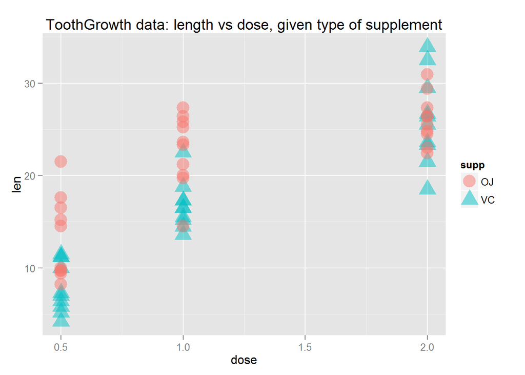

```r
print(ggplot(data=ToothGrowth, aes(x=dose, y=len, shape = supp, color=supp)) +
      ggtitle("ToothGrowth data: length vs dose, given type of supplement") +
      geom_point(size=6, alpha=0.5))
```

ToothGrowth dataset describes length of teeth 60 guinea pigs treated with Vitamin C. There were six groups of the animals: 10 guinea pigs at each of three dose levels of Vitamin C (0.5, 1, and 2 mg) with each of two delivery methods (orange juice or ascorbic acid).

# Confidence intervals

Visually we see that teeth length significantly higher for each level of supplement dose. Let’s see confidence intervals to see if it is indeed so, and intuitive comprehension of the chart doesn’t trick us.

We calculate change in mean of length for four pair of groups (change of does from 0.5 to 1.0 and from 1.0 to 2.0 for both types of delivery) and see if it lies within the t confidence interval.

```r
t.test(ToothGrowth$len[ToothGrowth$supp == "OJ" & ToothGrowth$dose == 1],
       ToothGrowth$len[ToothGrowth$supp == "OJ" & ToothGrowth$dose == 0.5]
       )$conf.int
```

```
## [1]  5.524366 13.415634
## attr(,"conf.level")
## [1] 0.95
```

```r
mean(ToothGrowth$len[ToothGrowth$supp == "OJ" & ToothGrowth$dose == 1]) -
        mean(ToothGrowth$len[ToothGrowth$supp == "OJ" & ToothGrowth$dose == 0.5])
```

```
## [1] 9.47
```

```r
t.test(ToothGrowth$len[ToothGrowth$supp == "OJ" & ToothGrowth$dose == 2],
       ToothGrowth$len[ToothGrowth$supp == "OJ" & ToothGrowth$dose == 1]
       )$conf.int
```

```
## [1] 0.1885575 6.5314425
## attr(,"conf.level")
## [1] 0.95
```

```r
mean(ToothGrowth$len[ToothGrowth$supp == "OJ" & ToothGrowth$dose == 2]) -
        mean(ToothGrowth$len[ToothGrowth$supp == "OJ" & ToothGrowth$dose == 1])
```

```
## [1] 3.36
```

```r
t.test(ToothGrowth$len[ToothGrowth$supp == "VC" & ToothGrowth$dose == 1],
       ToothGrowth$len[ToothGrowth$supp == "VC" & ToothGrowth$dose == 0.5]
       )$conf.int
```

```
## [1]  6.314288 11.265712
## attr(,"conf.level")
## [1] 0.95
```

```r
mean(ToothGrowth$len[ToothGrowth$supp == "VC" & ToothGrowth$dose == 1]) -
        mean(ToothGrowth$len[ToothGrowth$supp == "VC" & ToothGrowth$dose == 0.5])
```

```
## [1] 8.79
```

```r
t.test(ToothGrowth$len[ToothGrowth$supp == "VC" & ToothGrowth$dose == 2],
       ToothGrowth$len[ToothGrowth$supp == "VC" & ToothGrowth$dose == 1]
       )$conf.int
```

```
## [1]  5.685733 13.054267
## attr(,"conf.level")
## [1] 0.95
```

```r
mean(ToothGrowth$len[ToothGrowth$supp == "VC" & ToothGrowth$dose == 2]) -
        mean(ToothGrowth$len[ToothGrowth$supp == "VC" & ToothGrowth$dose == 1])
```

```
## [1] 9.37
```

It does indeed lies within in every case.

Does it matter if we take in account delivery method?

```r
t.test(ToothGrowth$len[ToothGrowth$dose == 1],
       ToothGrowth$len[ToothGrowth$dose == 0.5]
       )$conf.int
```

```
## [1]  6.276219 11.983781
## attr(,"conf.level")
## [1] 0.95
```

```r
mean(ToothGrowth$len[ToothGrowth$dose == 1]) -
        mean(ToothGrowth$len[ToothGrowth$dose == 0.5])
```

```
## [1] 9.13
```

```r
t.test(ToothGrowth$len[ToothGrowth$dose == 2],
       ToothGrowth$len[ToothGrowth$dose == 1]
       )$conf.int
```

```
## [1] 3.733519 8.996481
## attr(,"conf.level")
## [1] 0.95
```

```r
mean(ToothGrowth$len[ToothGrowth$dose == 2]) -
        mean(ToothGrowth$len[ToothGrowth$dose == 1])
```

```
## [1] 6.365
```

No, it doesn’t.

## Result

Assuming data is normally distributed, and using t distribution for safer approximation for small given number of observations, the confidence interval show that that change in teeth length is statistically significant for each level of dose increase, both with separate analysis of two different delivery ways, and mixed as well. Given this, we can say that vitamin C supplements do indeed increase tooth length in guinea pigs.